# K-Means, KNN, Decision Tree and SQL

```python
# Importing all required libraries
import numpy as np
import pandas as pd
import matplotlib.pyplot as plt
import seaborn as sns
import sqlite3
from sqlite3 import Error
from sklearn.preprocessing import StandardScaler        # encooding variables
from sklearn.cluster import KMeans                      # KMeans Clustering
import numpy as np
import matplotlib.image as mpimg
from sklearn.tree import DecisionTreeClassifier
from sklearn.model_selection import train_test_split
from sklearn import metrics
from sklearn.neighbors import KNeighborsClassifier
from sklearn import tree
from  io import StringIO
import pydotplus
from scipy import stats
%matplotlib inline
```

### 1.1 Preprocessing

To start off, bring in the data and get it ready for clustering. Your tasks are:

1. Import the Data. The dataset is available in the location data/cvss/CVSS_data_complete.csv
2. Prepare the data for a clustering task. This time you may encounter some missing or invalid values, hence you may have to decide how to tackle these as well. Note: This preprocessing section includes several tasks that will help you in your clustering and data analysis in future questions.

```python
# Importing the dataset
df = pd.read_csv('cvss_data_complete.csv')
```

```python
# Viewing first 5 rows
df.head()
```

|  | cve_id | assigner | description | cwe_ids | refs | ref_names | ref_sources | ref_tags | v3_attackVector | v3_attackComplexity | v3_privilegesRequired | v3_userInteraction | v3_scope | v3_confidentialityImpact | v3_integrityImpact | v3_availabilityImpact | v3_baseScore | v3_baseSeverity | v3_exploitabilityScore | v3_impactScore |
| --- | --- | --- | --- | --- | --- | --- | --- | --- | --- | --- | --- | --- | --- | --- | --- | --- | --- | --- | --- | --- |
| 0 | CVE-2020-0002 | security@android.com | In ih264d_init_decoder of ih264d_api.c, there ... | CWE-787,CWE-416 | https://source.android.com/security/bulletin/2... | https://source.android.com/security/bulletin/2... | CONFIRM | [['Patch', 'Vendor Advisory']] | NETWORK | LOW | NONE | REQUIRED | UNCHANGED | HIGH | HIGH | HIGH | 8.8 | HIGH | 2.8 | 5.9 |
| 1 | CVE-2020-0003 | security@android.com | In onCreate of InstallStart.java, there is a p... | CWE-367 | https://source.android.com/security/bulletin/2... | https://source.android.com/security/bulletin/2... | CONFIRM | [[]] | LOCAL | HIGH | LOW | REQUIRED | UNCHANGED | HIGH | HIGH | HIGH | 6.7 | MEDIUM | 0.8 | 5.9 |
| 2 | CVE-2020-0005 | security@android.com | In btm_read_remote_ext_features_complete of bt... | CWE-787 | https://source.android.com/security/bulletin/2... | https://source.android.com/security/bulletin/2... | MISC | [['Patch', 'Vendor Advisory']] | LOCAL | LOW | HIGH | NONE | UNCHANGED | HIGH | HIGH | HIGH | 6.7 | MEDIUM | 0.8 | 5.9 |
| 3 | CVE-2020-0006 | security@android.com | In rw_i93_send_cmd_write_single_block of rw_i9... | CWE-908 | https://source.android.com/security/bulletin/2... | https://source.android.com/security/bulletin/2... | CONFIRM | [['Patch', 'Vendor Advisory']] | NETWORK | LOW | NONE | REQUIRED | UNCHANGED | HIGH | NONE | NONE | 6.5 | MEDIUM | 2.8 | 3.6 |
| 4 | CVE-2020-0007 | security@android.com | In flattenString8 of Sensor.cpp, there is a po... | CWE-908 | https://source.android.com/security/bulletin/2... | https://source.android.com/security/bulletin/2... | CONFIRM | [['Vendor Advisory']] | LOCAL | LOW | LOW | NONE | UNCHANGED | HIGH | NONE | NONE | 5.5 | MEDIUM | 1.8 | 3.6 |

```python
# Check columns and their datatypes
df.info()
```

[output not shown]

[output cut: 16 more lines]

```python
# Describing continous data
df.describe().transpose()
```

|  | count | mean | std | min | 25% | 50% | 75% | max |
| --- | --- | --- | --- | --- | --- | --- | --- | --- |
| v3_baseScore | 9210.0 | 7.208458 | 1.708666 | 2.2 | 5.5 | 7.5 | 8.8 | 10.0 |
| v3_exploitabilityScore | 9210.0 | 2.679131 | 0.922228 | 0.3 | 1.8 | 2.8 | 3.9 | 3.9 |
| v3_impactScore | 9210.0 | 4.350185 | 1.519342 | 1.4 | 2.7 | 3.6 | 5.9 | 6.0 |

```python
# Checking for Duplicate rows
dup_percentage = df.duplicated().sum()/len(df)*100
dup_percentage = round(dup_percentage,2)
dup_percentage = dup_percentage.astype(str) + '%'
dup_percentage
```

```
'0.0%'
```

```python
# Checking for Missing values
percent_missing = df.isnull().sum() * 100 / len(df)
percent_missing = round(percent_missing, 2)
percent_missing = percent_missing.astype(str) + '%'
percent_missing
```

```
cve_id                       0.0%
assigner                     0.0%
description                  0.0%
cwe_ids                      0.0%
refs                         0.0%
ref_names                   2.02%
ref_sources                 1.35%
ref_tags                     0.0%
v3_attackVector              0.0%
v3_attackComplexity          0.0%
v3_privilegesRequired        0.0%
v3_userInteraction           0.0%
v3_scope                     0.0%
v3_confidentialityImpact     0.0%
v3_integrityImpact           0.0%
v3_availabilityImpact        0.0%
v3_baseScore                 0.0%
v3_baseSeverity              0.0%
v3_exploitabilityScore       0.0%
v3_impactScore               0.0%
dtype: object
```

```python
# Dropping rows with missing columns
df = df.dropna()
```

```python
# Inspect the categorical variables
df.select_dtypes('object').nunique()
```

```
cve_id                      9024
assigner                     116
description                 8740
cwe_ids                      291
refs                        7118
ref_names                   7075
ref_sources                  793
ref_tags                    2037
v3_attackVector                4
v3_attackComplexity            2
v3_privilegesRequired          3
v3_userInteraction             2
v3_scope                       2
v3_confidentialityImpact       3
v3_integrityImpact             3
v3_availabilityImpact          3
v3_baseSeverity                4
dtype: int64
```

```python
# Inspect the numerical variables
df.describe()
```

|  | v3_baseScore | v3_exploitabilityScore | v3_impactScore |
| --- | --- | --- | --- |
| count | 9024.000000 | 9024.000000 | 9024.000000 |
| mean | 7.202117 | 2.677804 | 4.344603 |
| std | 1.708961 | 0.922352 | 1.520360 |
| min | 2.200000 | 0.300000 | 1.400000 |
| 25% | 5.500000 | 1.800000 | 2.700000 |
| 50% | 7.500000 | 2.800000 | 3.600000 |
| 75% | 8.800000 | 3.900000 | 5.900000 |
| max | 10.000000 | 3.900000 | 6.000000 |

```python
# Filtering dataset
df1 = df[['v3_exploitabilityScore','v3_impactScore']]
# Show the data after pre-processing
print('Dimension data: {} rows and {} columns'.format(len(df1), len(df1.columns)))
df1.head()
```

```
Dimension data: 9024 rows and 2 columns
```

|  | v3_exploitabilityScore | v3_impactScore |
| --- | --- | --- |
| 0 | 2.8 | 5.9 |
| 1 | 0.8 | 5.9 |
| 2 | 0.8 | 5.9 |
| 3 | 2.8 | 3.6 |
| 4 | 1.8 | 3.6 |

```python
scaler = StandardScaler()
scaled_df = scaler.fit_transform(df1)
scaled_df
```

```
array([[ 0.1324908 ,  1.02310165],
       [-2.03599916,  1.02310165],
       [-2.03599916,  1.02310165],
       ...,
       [ 0.1324908 , -1.93688752],
       [ 0.1324908 , -1.08177953],
       [-0.95175418,  1.02310165]])
```

### 1.2 Building a Clustering Model

Clustering helps visualise a dataset based on attributes considered important to the data scientist and/or reader. Using the CVSS Dataset above, implement a K-Means clustering algorithm to cluster the dataset by using either all or a subset of the available features (except the Base Scores, Sub Scores and Base Severity). You are expected to reduce the dataset to either 2 or 3 dimensions. After you have prepared your learning model, plot a 2D or 3D visualisation showing the different clusters. It is up to you to decide how many clusters you would like to incorporate in your model. You are expected to verbally and visually justify your implementation, including the reasoning behind the choice of the number of clusters in your model.

```python
# Createa an empty list
wcss =[]

# Create all possible cluster solutions with a loop
for i in range(1,16):
    # Cluster solution with i clusters
    kmeans = KMeans(i)
    # Fit the STANDARDIZED data
    kmeans.fit(scaled_df)
    # Append the WCSS for the iteration
    wcss.append(kmeans.inertia_)

# Check the result
wcss
```

```
[18048.00000000044,
 10037.62670695744,
 5174.495507186649,
 3420.554830661222,
 2479.056080436212,
 1597.827240572321,
 1306.194259824574,
 1035.790918597091,
 843.1116150080506,
 679.3916375381986,
 530.9614214897822,
 396.537918302464,
 295.4845748950676,
 227.20419002561852,
 201.3411341851242]
```

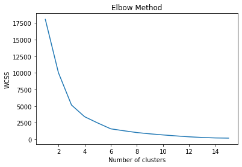

```python
# Plot the number of clusters vs WCSS
plt.plot(range(1,16),wcss)
# Name your axes
plt.title("Elbow Method")
plt.xlabel('Number of clusters')
plt.ylabel('WCSS')
```

##### Selecting Number of Clusters as 3:

From the above plot we can see according to the elbow method, the ideal cluster that should be chosen is 3

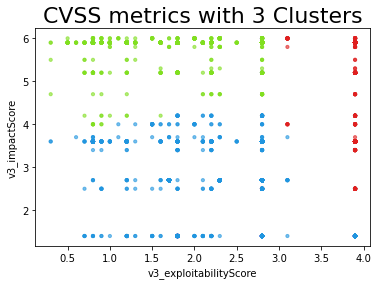

```python
# k means
kmeans = KMeans(n_clusters=3, random_state=0)
df['cluster3'] = kmeans.fit_predict(scaled_df)
# get centroids
centroids = kmeans.cluster_centers_
cen_x = [i[0] for i in centroids]
cen_y = [i[1] for i in centroids]
## add to df
df['cen_x2'] = df.cluster3.map({0:cen_x[0], 1:cen_x[1], 2:cen_x[2]})
df['cen_y2'] = df.cluster3.map({0:cen_y[0], 1:cen_y[1], 2:cen_y[2]})
# define and map colors
colors = ['#DF2020', '#81DF20', '#2095DF']
df['c2'] = df.cluster3.map({0:colors[0], 1:colors[1], 2:colors[2]})
plt.scatter(df.v3_exploitabilityScore, df.v3_impactScore, c=df.c2, alpha = 0.6, s=10)
# title and labels
plt.title('CVSS metrics with 3 Clusters', fontsize=22)
plt.xlabel('v3_exploitabilityScore')
plt.ylabel('v3_impactScore')
```

### 1.3 Analysing the Clusters:

#### 1.3.1 Comparison of summary statistics between clusters

1. Display and compare the mean of the CVSS Base Score, between all clusters in your model.
2. Identify and explain the largest differences in metrics (including the mean of the CVSS Base Scores) between the clusters using a suitable summary statistic(s). (i.e. what are the defining characteristics of a cluster compared to other cluster(s)?)

```python
df_stats = df[['cluster3','v3_baseScore']]
```

```python
grouped_df = df_stats.groupby(['cluster3']).mean()
```

```python
print(grouped_df)
```

```
          v3_baseScore
cluster3
0             8.918069
1             8.011883
2             5.525896
```

```python
df.describe()
```

|  | v3_baseScore | v3_exploitabilityScore | v3_impactScore | cluster3 | cen_x2 | cen_y2 |
| --- | --- | --- | --- | --- | --- | --- |
| count | 9024.000000 | 9024.000000 | 9024.000000 | 9024.000000 | 9.024000e+03 | 9.024000e+03 |
| mean | 7.202117 | 2.677804 | 4.344603 | 1.155031 | -2.050074e-15 | 1.040551e-15 |
| std | 1.708961 | 0.922352 | 1.520360 | 0.817499 | 8.116263e-01 | 8.763932e-01 |
| min | 2.200000 | 0.300000 | 1.400000 | 0.000000 | -6.887164e-01 | -9.931356e-01 |
| 25% | 5.500000 | 1.800000 | 2.700000 | 0.000000 | -6.887164e-01 | -9.931356e-01 |
| 50% | 7.500000 | 2.800000 | 3.600000 | 1.000000 | -3.342762e-01 | 4.376979e-01 |
| 75% | 8.800000 | 3.900000 | 5.900000 | 2.000000 | 1.316214e+00 | 9.851558e-01 |
| max | 10.000000 | 3.900000 | 6.000000 | 2.000000 | 1.316214e+00 | 9.851558e-01 |

#### 1.3.2 Visual exploration of the distribution of Base Scores between clusters

- (a) Visualise the distribution of the CVSS Base Score between each cluster.
- (b) Answer the following: Without the use of a hypothesis test, does the CVSS Base Score appear to differ significantly between these clusters? (You may reference the previous question (a) rather than reproducing answers)

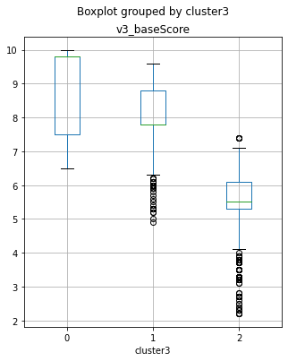

```python
df_stats.boxplot(column='v3_baseScore', by='cluster3', figsize=(5,6))
```

Answer (b): Based on the Summary Statistics, we can see the out of the 3 clusters, it significantly varies in 3rd cluster but not so much in 1st and 2nd Cluster

### 1.4 Comparing our model prediction based on Base Severity values

Do the cluster labels accurately categorise the Base Severity? Since you know the actual Base Severity classification values for this dataset, can you now compare the model predictions with the actual Base Severity values?

- **HINT:** Present the Base Severity counts of the clusters found by the model by plotting the actual Base Severity groups and predicted clusters side by side
- **NOTE:** The number of unique Base Severity groups and the number of clusters in your trained model may be different.

```python
df_base_severety = df[['cluster3','v3_baseSeverity']]
df_base_severety
```

|  | cluster3 | v3_baseSeverity |
| --- | --- | --- |
| 0 | 1 | HIGH |
| 1 | 1 | MEDIUM |
| 2 | 1 | MEDIUM |
| 3 | 2 | MEDIUM |
| 4 | 2 | MEDIUM |
| ... | ... | ... |
| 9205 | 2 | MEDIUM |
| 9206 | 1 | HIGH |
| 9207 | 2 | MEDIUM |
| 9208 | 2 | MEDIUM |
| 9209 | 1 | HIGH |

9024 rows × 2 columns

```python
import seaborn as sns
```

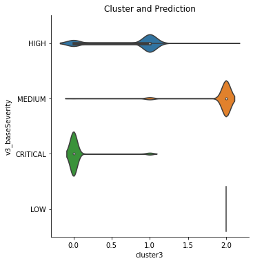

```python
sns.catplot(y="v3_baseSeverity", x="cluster3",kind="violin", data=df_base_severety).set(title='Cluster and Prediction')
```

```python
df_base_severety_count = df_base_severety.groupby(['cluster3'], as_index=False).count()
df_base_severety_count
```

|  | cluster3 | v3_baseSeverity |
| --- | --- | --- |
| 0 | 0 | 2424 |
| 1 | 1 | 2777 |
| 2 | 2 | 3823 |

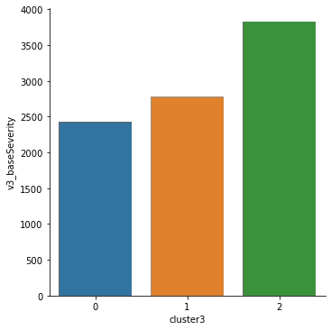

```python
sns.catplot(y="v3_baseSeverity", x="cluster3",kind="bar", data=df_base_severety_count)
```

### 2.1: Load and process the data

Your first task is to load and pre-process the data for the classifciation task. Remember that we are asking you to predict whether a given record is ransom (i.e., known to be ransomware). The data to be loaded is found in data/BitcoinHeistDataSample.csv.

```python
df_bitcoin = pd.read_csv('BitcoinHeistDataSample.csv')
```

```python
df_bitcoin.head()
```

|  | address | year | day | length | weight | count | looped | neighbors | income | label |
| --- | --- | --- | --- | --- | --- | --- | --- | --- | --- | --- |
| 0 | 18uMmC74nRJdWUEHxbDJgm8VWMteQN68S1 | 2014 | 2 | 38 | 0.166997 | 9 | 0 | 1 | 3.778000e+07 | white |
| 1 | 16ucAymaXwPpMVdXtA4FE9sWQH7RrK4P8v | 2014 | 105 | 144 | 6.129424 | 1906 | 1889 | 16 | 3.291332e+10 | paduaCryptoWall |
| 2 | 1HwKwCYZHZZnGAn6t6pRUPVtq71mPwGTXc | 2012 | 17 | 0 | 1.000000 | 1 | 0 | 1 | 1.100000e+09 | white |
| 3 | 1MsCsEPC43GC3j2GA96nV36NysKX747tE | 2014 | 172 | 144 | 0.680399 | 853 | 771 | 2 | 2.130000e+09 | paduaCryptoWall |
| 4 | 15Jjgw3fjg2H2KkZjKZrPHP2hHautmdWaf | 2017 | 23 | 144 | 0.012218 | 3880 | 0 | 2 | 4.213180e+07 | white |

```python
# Checking for Duplicate rows
dup_percentage = df_bitcoin.duplicated().sum()/len(df_bitcoin)*100
dup_percentage = round(dup_percentage,2)
dup_percentage = dup_percentage.astype(str) + '%'
dup_percentage
```

```
'0.0%'
```

```python
# Checking for Missing values
percent_missing = df_bitcoin.isnull().sum() * 100 / len(df_bitcoin)
percent_missing = round(percent_missing, 2)
percent_missing = percent_missing.astype(str) + '%'
percent_missing
```

```
address      0.0%
year         0.0%
day          0.0%
length       0.0%
weight       0.0%
count        0.0%
looped       0.0%
neighbors    0.0%
income       0.0%
label        0.0%
dtype: object
```

```python
# Renaming all ransomware families to ransomware
df_bitcoin['label'] = df_bitcoin['label'].replace(['paduaCryptoWall', 'montrealCryptoLocker', 'princetonCerber', 'princetonLocky','montrealCryptXXX'], ['ransomware','ransomware','ransomware','ransomware','ransomware'])
df_bitcoin['label'] = df_bitcoin['label'].replace(['montrealNoobCrypt', 'montrealDMALocker', 'montrealDMALockerv3', 'montrealSamSam','montrealGlobev3'], ['ransomware','ransomware','ransomware','ransomware','ransomware'])
df_bitcoin['label'] = df_bitcoin['label'].replace(['montrealCryptoTorLocker2015', 'montrealAPT', 'montrealGlobeImposter', 'montrealGlobe','montrealWannaCry'], ['ransomware','ransomware','ransomware','ransomware','ransomware'])
df_bitcoin['label'] = df_bitcoin['label'].replace(['montrealXTPLocker', 'montrealCryptConsole', 'montrealVenusLocker', 'paduaJigsaw','montrealRazy'], ['ransomware','ransomware','ransomware','ransomware','ransomware'])
df_bitcoin['label'] = df_bitcoin['label'].replace(['paduaKeRanger', 'montrealEDA2'], ['ransomware','ransomware'])
df_bitcoin.head()
```

|  | address | year | day | length | weight | count | looped | neighbors | income | label |
| --- | --- | --- | --- | --- | --- | --- | --- | --- | --- | --- |
| 0 | 18uMmC74nRJdWUEHxbDJgm8VWMteQN68S1 | 2014 | 2 | 38 | 0.166997 | 9 | 0 | 1 | 3.778000e+07 | white |
| 1 | 16ucAymaXwPpMVdXtA4FE9sWQH7RrK4P8v | 2014 | 105 | 144 | 6.129424 | 1906 | 1889 | 16 | 3.291332e+10 | ransomware |
| 2 | 1HwKwCYZHZZnGAn6t6pRUPVtq71mPwGTXc | 2012 | 17 | 0 | 1.000000 | 1 | 0 | 1 | 1.100000e+09 | white |
| 3 | 1MsCsEPC43GC3j2GA96nV36NysKX747tE | 2014 | 172 | 144 | 0.680399 | 853 | 771 | 2 | 2.130000e+09 | ransomware |
| 4 | 15Jjgw3fjg2H2KkZjKZrPHP2hHautmdWaf | 2017 | 23 | 144 | 0.012218 | 3880 | 0 | 2 | 4.213180e+07 | white |

### 2.2 Data Analysis and Visualisation

We are interested in looking at how the volume of ransom and white data points differ across the years in this sample dataset. Your task is to come up with a suitable plot to visualise this and comment on your observations. NOTE: The dataset is a sub-set of the original dataset that is not representative of the real spread between the actual labels. Hence, the conclusions we can reach based on the above plot may not hold for the full dataset, which is out of scope for this question.

```python
# Grouping data
grouped_df_bitcoin = df_bitcoin.groupby(['year','label'], as_index=False).sum()
grouped_df_bitcoin
```

|  | year | label | day | length | weight | count | looped | neighbors | income |
| --- | --- | --- | --- | --- | --- | --- | --- | --- | --- |
| 0 | 2011 | ransomware | 4153 | 248 | 4.808148 | 147 | 0 | 37 | 3.095154e+09 |
| 1 | 2011 | white | 115287 | 14050 | 255.718501 | 8880 | 1238 | 1104 | 4.405631e+12 |
| 2 | 2012 | ransomware | 20649 | 1638 | 25.028228 | 895 | 99 | 187 | 6.378292e+10 |
| 3 | 2012 | white | 106789 | 15858 | 345.237146 | 93558 | 31386 | 1963 | 8.752510e+12 |
| 4 | 2013 | ransomware | 259940 | 31146 | 913.175886 | 318701 | 86150 | 3041 | 2.030959e+12 |
| 5 | 2013 | white | 115459 | 17442 | 319.859072 | 142740 | 34559 | 1161 | 1.935230e+12 |
| 6 | 2014 | ransomware | 138940 | 52372 | 1086.203666 | 414926 | 153040 | 2573 | 1.031856e+12 |
| 7 | 2014 | white | 126198 | 45468 | 295.336685 | 434459 | 280540 | 1390 | 9.636729e+11 |
| 8 | 2015 | ransomware | 91511 | 20646 | 202.758180 | 251748 | 49483 | 651 | 1.259956e+11 |
| 9 | 2015 | white | 124037 | 47812 | 401.107201 | 739030 | 346740 | 1460 | 2.375717e+12 |
| 10 | 2016 | ransomware | 344930 | 88220 | 670.256207 | 1707921 | 143342 | 3121 | 3.414896e+11 |
| 11 | 2016 | white | 110737 | 31422 | 338.876492 | 711974 | 256109 | 1331 | 9.458093e+11 |
| 12 | 2017 | ransomware | 35328 | 15312 | 119.897085 | 313824 | 32474 | 785 | 4.588462e+10 |
| 13 | 2017 | white | 122879 | 31292 | 353.348590 | 791580 | 153107 | 1315 | 7.481211e+11 |
| 14 | 2018 | ransomware | 134 | 140 | 0.155440 | 6345 | 0 | 1 | 1.178321e+08 |
| 15 | 2018 | white | 91909 | 27906 | 328.645301 | 835532 | 147089 | 1055 | 5.302798e+11 |

```python
# creating a pivot table
grouped_df_bitcoin_pivot = grouped_df_bitcoin.pivot(index='year',columns='label',values='looped') #Creating Pivot Table
grouped_df_bitcoin_pivot
```

| label year | ransomware | white |
| --- | --- | --- |
| 2011 | 0 | 1238 |
| 2012 | 99 | 31386 |
| 2013 | 86150 | 34559 |
| 2014 | 153040 | 280540 |
| 2015 | 49483 | 346740 |
| 2016 | 143342 | 256109 |
| 2017 | 32474 | 153107 |
| 2018 | 0 | 147089 |

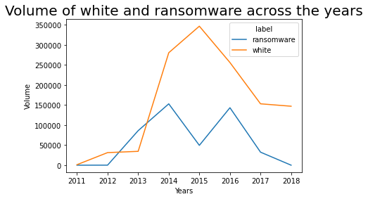

```python
# Visualising the line chart to show the volume of ransomware and years across the years
grouped_df_bitcoin_pivot.plot(kind='line')
plt.title("Volume of white and ransomware across the years", fontsize= 20)
plt.xlabel('Years')
plt.ylabel('Volume')
```

### 2.3: Classification using k-Nearest Neighbors

Train a KNN model using this dataset to predict whether a given record is ransom (i.e., known to be ransomware).

```python
# Making label data set to 0 and 1
df_bitcoin['Target'] = df_bitcoin['label'].map({'white':0,'ransomware':1})
df_bitcoin.head()
```

|  | address | year | day | length | weight | count | looped | neighbors | income | label | Target |
| --- | --- | --- | --- | --- | --- | --- | --- | --- | --- | --- | --- |
| 0 | 18uMmC74nRJdWUEHxbDJgm8VWMteQN68S1 | 2014 | 2 | 38 | 0.166997 | 9 | 0 | 1 | 3.778000e+07 | white | 0 |
| 1 | 16ucAymaXwPpMVdXtA4FE9sWQH7RrK4P8v | 2014 | 105 | 144 | 6.129424 | 1906 | 1889 | 16 | 3.291332e+10 | ransomware | 1 |
| 2 | 1HwKwCYZHZZnGAn6t6pRUPVtq71mPwGTXc | 2012 | 17 | 0 | 1.000000 | 1 | 0 | 1 | 1.100000e+09 | white | 0 |
| 3 | 1MsCsEPC43GC3j2GA96nV36NysKX747tE | 2014 | 172 | 144 | 0.680399 | 853 | 771 | 2 | 2.130000e+09 | ransomware | 1 |
| 4 | 15Jjgw3fjg2H2KkZjKZrPHP2hHautmdWaf | 2017 | 23 | 144 | 0.012218 | 3880 | 0 | 2 | 4.213180e+07 | white | 0 |

```python
# Viewing correlation of Target with other variables
np.abs(df_bitcoin.corr()['Target'])
```

```
year         0.096935
day          0.017755
length       0.036408
weight       0.029206
count        0.046819
looped       0.101030
neighbors    0.006327
income       0.033462
Target       1.000000
Name: Target, dtype: float64
```

**Split the data into features and labels, and then split into a training set and test set, with 70% for Cross-Validation training, and 30% for a final test set.**

```python
# Selecting variables based on correlation
X = df_bitcoin.drop(['Target','label','address','neighbors'],axis=1)
y = df_bitcoin['label']
```

```python
# Creating train-test dataset split
X_cv, X_test, y_cv, y_test = train_test_split(X, y, test_size=0.3, random_state=42)
```

**Creating a PipeLine that contains both a StandardScaler and a KNN model**

```python
scaler = StandardScaler()
```

```python
knn = KNeighborsClassifier()
```

```python
operations = [('scaler',scaler),('knn',knn)]
```

```python
from sklearn.pipeline import Pipeline
pipe = Pipeline(operations)
```

**Performing a grid-search with the pipeline to test various values of k and report back the best performing parameters.**

```python
k_values = list(range(1,30))
```

```python
param_grid = {'knn__n_neighbors': k_values}
```

```python
from sklearn.model_selection import GridSearchCV
```

```python
full_cv_classifier = GridSearchCV(pipe,param_grid,cv=5,scoring='accuracy')
```

```python
full_cv_classifier.fit(X_cv,y_cv)
```

```
GridSearchCV(cv=5,
             estimator=Pipeline(steps=[('scaler', StandardScaler()),
                                       ('knn', KNeighborsClassifier())]),
             param_grid={'knn__n_neighbors': [1, 2, 3, 4, 5, 6, 7, 8, 9, 10, 11,
                                              12, 13, 14, 15, 16, 17, 18, 19,
                                              20, 21, 22, 23, 24, 25, 26, 27,
                                              28, 29]},
             scoring='accuracy')
```

```python
full_cv_classifier.best_estimator_.get_params()
```

```
{'memory': None,
 'steps': [('scaler', StandardScaler()),
  ('knn', KNeighborsClassifier(n_neighbors=16))],
 'verbose': False,
 'scaler': StandardScaler(),
 'knn': KNeighborsClassifier(n_neighbors=16),
 'scaler__copy': True,
 'scaler__with_mean': True,
 'scaler__with_std': True,
 'knn__algorithm': 'auto',
 'knn__leaf_size': 30,
 'knn__metric': 'minkowski',
 'knn__metric_params': None,
 'knn__n_jobs': None,
 'knn__n_neighbors': 16,
 'knn__p': 2,
 'knn__weights': 'uniform'}
```

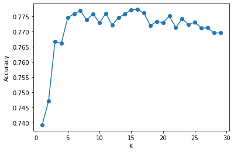

```python
scores = full_cv_classifier.cv_results_['mean_test_score']
plt.plot(k_values,scores,'o-')
plt.xlabel("K")
plt.ylabel("Accuracy")
```

```python
print( "The best accuracy was with k=",full_cv_classifier.cv_results_['mean_test_score'].argmax()+1)
```

```
The best accuracy was with k= 16
```

**Using the grid classifier object from the previous step, get a final performance classification report and confusion matrix.**

```python
pred = full_cv_classifier.predict(X_test)
```

### 2.4: Classification using Decision trees

Train a Decision Tree model using this dataset to predict whether a given record is ransom (i.e., known to be ransomware).

- How did you prepare the dataset for this task?
- **Ans**: The data was prepared the sameway it was for KNN Classification
- What are the hyperparameters of your model?
- **Ans**: The hyperparameters of the model was criterion='entropy', max_depth=12
- How did you decide on the hyperparameters for your model?
- **Ans**: The hyperparameters were selected on the basis of the result produced by GridSearch Method

Visualise the decision tree that you trained (display the tree in the notebook, you may optionally save this as a figure; If you save the tree as a figure, you should include the figure in the img folder, and import it into a markdown box in your notebook. You can use the command (./img/tree.png) where tree.png is the name of your figure.) • Print the validation, training and testing scores for your model

**Create a PipeLine that contains both a StandardScaler and a DecisionTree model**

```python
dec_tree = tree.DecisionTreeClassifier()
```

```python
operations = [('scaler',scaler),('dec_tree',dec_tree)]
```

```python
pipe = Pipeline(operations)
```

```python
# DecisionTreeClassifier requires two parameters 'criterion' and 'max_depth' to be optimised by GridSearchCV.
# So we have set these two parameters as a list of values form which GridSearchCV will select the best value of parameter.
criterion = ['gini', 'entropy']
max_depth = [2,4,6,8,10,12]
```

```python
parameters = dict(dec_tree__criterion=criterion, dec_tree__max_depth=max_depth)
```

```python
clf_GS = GridSearchCV(pipe, parameters)
```

```python
clf_GS.fit(X, y)
```

```
GridSearchCV(estimator=Pipeline(steps=[('scaler', StandardScaler()),
                                       ('dec_tree', DecisionTreeClassifier())]),
             param_grid={'dec_tree__criterion': ['gini', 'entropy'],
                         'dec_tree__max_depth': [2, 4, 6, 8, 10, 12]})
```

```python
print('Best Criterion:', clf_GS.best_estimator_.get_params()['dec_tree__criterion'])
print('Best max_depth:', clf_GS.best_estimator_.get_params()['dec_tree__max_depth'])
print(clf_GS.best_estimator_.get_params()['dec_tree'])
```

```
Best Criterion: entropy
Best max_depth: 12
DecisionTreeClassifier(criterion='entropy', max_depth=12)
```

```python
# Creating a decision tree instance with optimal parameters
ransomTree = DecisionTreeClassifier(criterion="entropy", max_depth = 12)
ransomTree # it shows the default parameters
```

```
DecisionTreeClassifier(criterion='entropy', max_depth=12)
```

```python
# Fitting training data into the instance
ransomTree.fit(X_cv,y_cv)
```

```
DecisionTreeClassifier(criterion='entropy', max_depth=12)
```

```python
# Making predictions using the test data
predTree = ransomTree.predict(X_test)
```

```python
# Comparing test and predicted datavalues
print (predTree [0:5])
print (y_cv [0:5])
```

```
['white' 'white' 'white' 'white' 'ransomware']
9069    ransomware
2603         white
7738    ransomware
1579    ransomware
5058         white
Name: label, dtype: object
```

```python
# Checking Model Accuracy
print("DecisionTrees's Accuracy: ", metrics.accuracy_score(y_test, predTree))
```

```
DecisionTrees's Accuracy:  0.813
```

```python
# Filtering dataset to create a decision tree diagram
df_tree = df_bitcoin[['year', 'day','length','weight','count','looped','income','label']].copy()
```

[figure not shown]

```python
# Visualizing the Decision Tree
dot_data = StringIO()
filename = "ransomtree.png"
featureNames = df_tree.columns[0:7]
out=tree.export_graphviz(ransomTree,feature_names=featureNames, out_file=dot_data, class_names= np.unique(y_cv), filled=True,  special_characters=True,rotate=False)
graph = pydotplus.graph_from_dot_data(dot_data.getvalue())
graph.write_png(filename)
img = mpimg.imread(filename)
plt.figure(figsize=(100, 300))
plt.imshow(img,interpolation='nearest')
```

### 2.5: Model comparision

Compare the performance of the two models that you trained in 2.3 and 2.4.

- Include the Confusion Matrix, Accuracy, Precision, Recall and F1-scores in your comparision.
- Which model is better based on the metrics you obtained? Ans: Decision Tree
- Discuss the performance of the two models in terms of the False Negatives and False Positives (assume that we consider False Negatives (incorrectly classifying a ransom record as white) are more harmful than False Positives (incorrectly classifying white record as ransom))

```python
from sklearn.metrics import classification_report,confusion_matrix,accuracy_score
```

```python
print("Decision Tree")
print(classification_report(y_test,predTree))
```

```
Decision Tree
              precision    recall  f1-score   support

  ransomware       0.79      0.86      0.82      1497
       white       0.84      0.77      0.81      1503

    accuracy                           0.81      3000
   macro avg       0.82      0.81      0.81      3000
weighted avg       0.82      0.81      0.81      3000
```

```python
# Decision tree has classied by positive values more accurate compared to negative values
confusion_matrix(y_test,predTree)
```

```
array([[1280,  217],
       [ 344, 1159]], dtype=int64)
```

```python
print("KNN")
print(classification_report(y_test,pred))
```

```
KNN
              precision    recall  f1-score   support

  ransomware       0.72      0.87      0.79      1497
       white       0.84      0.66      0.74      1503

    accuracy                           0.77      3000
   macro avg       0.78      0.77      0.76      3000
weighted avg       0.78      0.77      0.76      3000
```

```python
# KNN has classied by positive values more accurately compared to negative values
confusion_matrix(y_test,pred)
```

```
array([[1302,  195],
       [ 508,  995]], dtype=int64)
```

## Q3: Serious SQL

```python
# THIS IS YOUR CONNECTION BLOCK, DO NOT MODIFY THIS.
# OTHERWISE, YOU WILL NOT BE ABLE TO READ THE DATABASE
def create_connection(db_file):
    """ Connect to the specified SQLite database, if not exist, create a new one;
    :db_file: location of db to connect to
    :return: Connection object or None
    """
    conn = None
    try:
        conn = sqlite3.connect(db_file)
        print("Connection established!")

    except Error as e:
        print("Error Connecting to Database")
        raise(e)
    return conn

sakila_db = 'sqlite-sakila.db'
conn = create_connection(sakila_db)
cur = conn.cursor()
# remember to close the connection when everything is done
```

```
Connection established!
```

### 3.1: Names of the tables

List the names of the tables found in this database.

```python
pd.read_sql("""select *
               from sqlite_schema
               where type = 'table';""", conn)
```

|  | type | name | tbl_name | rootpage | sql |
| --- | --- | --- | --- | --- | --- |
| 0 | table | actor | actor | 2 | CREATE TABLE actor (\n actor_id numeric NOT N... |
| 1 | table | country | country | 5 | CREATE TABLE country (\n country_id SMALLINT ... |
| 2 | table | city | city | 7 | CREATE TABLE city (\n city_id int NOT NULL,\n... |
| 3 | table | address | address | 10 | CREATE TABLE address (\n address_id int NOT N... |
| 4 | table | language | language | 13 | CREATE TABLE language (\n language_id SMALLIN... |
| 5 | table | category | category | 15 | CREATE TABLE category (\n category_id SMALLIN... |
| 6 | table | customer | customer | 19 | CREATE TABLE customer (\n customer_id INT NOT... |
| 7 | table | film | film | 24 | CREATE TABLE film (\n film_id int NOT NULL,\n... |
| 8 | table | film_actor | film_actor | 28 | CREATE TABLE film_actor (\n actor_id INT NOT ... |
| 9 | table | film_category | film_category | 33 | CREATE TABLE film_category (\n film_id INT NO... |
| 10 | table | film_text | film_text | 37 | CREATE TABLE film_text (\n film_id SMALLINT N... |
| 11 | table | inventory | inventory | 39 | CREATE TABLE inventory (\n inventory_id INT N... |
| 12 | table | staff | staff | 43 | CREATE TABLE staff (\n staff_id SMALLINT NOT ... |
| 13 | table | store | store | 48 | CREATE TABLE store (\n store_id INT NOT NULL,... |
| 14 | table | payment | payment | 52 | CREATE TABLE payment (\n payment_id int NOT N... |
| 15 | table | rental | rental | 56 | CREATE TABLE rental (\n rental_id INT NOT NUL... |

### 3.2: Number of Customers

List the number of customers in the database.

```python
pd.read_sql("""select COUNT(*) counter
               from customer;""", conn)
```

|  | counter |
| --- | --- |
| 0 | 599 |

### 3.3: Films with PG rating

What are the titles and descriptions of films with a PG rating?

```python
pd.read_sql("""select title,description
               from film
               where rating = 'PG';""", conn)
```

|  | title | description |
| --- | --- | --- |
| 0 | ACADEMY DINOSAUR | A Epic Drama of a Feminist And a Mad Scientist... |
| 1 | AGENT TRUMAN | A Intrepid Panorama of a Robot And a Boy who m... |
| 2 | ALASKA PHANTOM | A Fanciful Saga of a Hunter And a Pastry Chef ... |
| 3 | ALI FOREVER | A Action-Packed Drama of a Dentist And a Croco... |
| 4 | AMADEUS HOLY | A Emotional Display of a Pioneer And a Technic... |
| ... | ... | ... |
| 189 | WIZARD COLDBLOODED | A Lacklusture Display of a Robot And a Girl wh... |
| 190 | WON DARES | A Unbelieveable Documentary of a Teacher And a... |
| 191 | WONDERLAND CHRISTMAS | A Awe-Inspiring Character Study of a Waitress ... |
| 192 | WORDS HUNTER | A Action-Packed Reflection of a Composer And a... |
| 193 | WORST BANGER | A Thrilling Drama of a Madman And a Dentist wh... |

194 rows × 2 columns

### 3.4: Films by category

What are the counts of films for each category in the database? Display the category names with the number of films in each category.

```python
pd.read_sql("""select category.name, count(film_category.film_id) counter
               from category,film_category
               on film_category.category_id = category.category_id
               group by category.name;""", conn)
```

|  | name | counter |
| --- | --- | --- |
| 0 | Action | 64 |
| 1 | Animation | 66 |
| 2 | Children | 60 |
| 3 | Classics | 57 |
| 4 | Comedy | 58 |
| 5 | Documentary | 68 |
| 6 | Drama | 62 |
| 7 | Family | 69 |
| 8 | Foreign | 73 |
| 9 | Games | 61 |
| 10 | Horror | 56 |
| 11 | Music | 51 |
| 12 | New | 63 |
| 13 | Sci-Fi | 61 |
| 14 | Sports | 74 |
| 15 | Travel | 57 |

### 3.5: Most rented

Find the details of the top film in the database as measured by the most number of rentals.

```python
pd.read_sql("""select title,description,release_year,count(rental.rental_id) as rented
               from inventory
               join film
               on inventory.film_id = film.film_id
               join rental
               on inventory.inventory_id = rental.inventory_id
               group by title
               order by rented DESC;""", conn)
```

|  | title | description | release_year | rented |
| --- | --- | --- | --- | --- |
| 0 | BUCKET BROTHERHOOD | A Amazing Display of a Girl And a Womanizer wh... | 2006 | 34 |
| 1 | ROCKETEER MOTHER | A Awe-Inspiring Character Study of a Robot And... | 2006 | 33 |
| 2 | SCALAWAG DUCK | A Fateful Reflection of a Car And a Teacher wh... | 2006 | 32 |
| 3 | RIDGEMONT SUBMARINE | A Unbelieveable Drama of a Waitress And a Comp... | 2006 | 32 |
| 4 | JUGGLER HARDLY | A Epic Story of a Mad Cow And a Astronaut who ... | 2006 | 32 |
| ... | ... | ... | ... | ... |
| 953 | BUNCH MINDS | A Emotional Story of a Feminist And a Feminist... | 2006 | 5 |
| 954 | BRAVEHEART HUMAN | A Insightful Story of a Dog And a Pastry Chef ... | 2006 | 5 |
| 955 | TRAIN BUNCH | A Thrilling Character Study of a Robot And a S... | 2006 | 4 |
| 956 | MIXED DOORS | A Taut Drama of a Womanizer And a Lumberjack w... | 2006 | 4 |
| 957 | HARDLY ROBBERS | A Emotional Character Study of a Hunter And a ... | 2006 | 4 |

958 rows × 4 columns

### 3.6: Not returned rentals

Find out how many rentals have not yet been returned.

```python
pd.read_sql("""select count(rental_id) as return_pending
               from rental
               where return_date IS NULL;""", conn)
```

|  | return_pending |
| --- | --- |
| 0 | 183 |

### 3.7: Finding a customer

List the film titles that the customer BARBARA JONES has rented.

```python
pd.read_sql("""select film.title as movie_rented from film
               join inventory
               on film.film_id = inventory.film_id
               join rental
               on rental.inventory_id = inventory.inventory_id
               join customer
               on customer.customer_id = rental.customer_id
               where customer.first_name = 'BARBARA'
               and customer.last_name = 'JONES';""", conn)
```

|  | movie_rented |
| --- | --- |
| 0 | DOGMA FAMILY |
| 1 | BEDAZZLED MARRIED |
| 2 | ARTIST COLDBLOODED |
| 3 | AMADEUS HOLY |
| 4 | MAGIC MALLRATS |
| 5 | IDAHO LOVE |
| 6 | WARDROBE PHANTOM |
| 7 | SHANGHAI TYCOON |
| 8 | ARACHNOPHOBIA ROLLERCOASTER |
| 9 | TOMORROW HUSTLER |
| 10 | PANIC CLUB |
| 11 | ALAMO VIDEOTAPE |
| 12 | VERTIGO NORTHWEST |
| 13 | PHILADELPHIA WIFE |
| 14 | HOOSIERS BIRDCAGE |
| 15 | MADIGAN DORADO |
| 16 | ANNIE IDENTITY |
| 17 | ROLLERCOASTER BRINGING |
| 18 | STAGE WORLD |
| 19 | DEEP CRUSADE |
| 20 | MARRIED GO |
| 21 | REUNION WITCHES |

```python
# Closing database connection
conn.close()
```